# Untitled

#Please use the attached dataset on loan approval status to predict loan approval using Decision Trees. Please be sure to conduct a thorough exploratory analysis to start the task and walk us through your reasoning behind all the steps you are taking. (40 points)

```r
library(tidyverse)
library(dplyr)
library(caret)
library(pROC)
library(nnet)
library(forcats)
library(knitr)
library(rpart)
```

# Import Data

```r
loan <- read.csv("https://raw.githubusercontent.com/Zchen116/data-622/main/Loan_approval.csv")
```

```r
head(loan)
```

```
##    Loan_ID Gender Married Dependents    Education Self_Employed ApplicantIncome
## 1 LP001002   Male      No          0     Graduate            No            5849
## 2 LP001003   Male     Yes          1     Graduate            No            4583
## 3 LP001005   Male     Yes          0     Graduate           Yes            3000
## 4 LP001006   Male     Yes          0 Not Graduate            No            2583
## 5 LP001008   Male      No          0     Graduate            No            6000
## 6 LP001011   Male     Yes          2     Graduate           Yes            5417
##   CoapplicantIncome LoanAmount Loan_Amount_Term Credit_History Property_Area
## 1                 0         NA              360              1         Urban
## 2              1508        128              360              1         Rural
## 3                 0         66              360              1         Urban
## 4              2358        120              360              1         Urban
## 5                 0        141              360              1         Urban
## 6              4196        267              360              1         Urban
##   Loan_Status
## 1           Y
## 2           N
## 3           Y
## 4           Y
## 5           Y
## 6           Y
```

```r
summary(loan)
```

```
##    Loan_ID             Gender            Married           Dependents
##  Length:614         Length:614         Length:614         Length:614
##  Class :character   Class :character   Class :character   Class :character
##  Mode  :character   Mode  :character   Mode  :character   Mode  :character
##
##
##
##
##   Education         Self_Employed      ApplicantIncome CoapplicantIncome
##  Length:614         Length:614         Min.   :  150   Min.   :    0
##  Class :character   Class :character   1st Qu.: 2878   1st Qu.:    0
##  Mode  :character   Mode  :character   Median : 3812   Median : 1188
##                                        Mean   : 5403   Mean   : 1621
##                                        3rd Qu.: 5795   3rd Qu.: 2297
##                                        Max.   :81000   Max.   :41667
##
##    LoanAmount    Loan_Amount_Term Credit_History   Property_Area
##  Min.   :  9.0   Min.   : 12      Min.   :0.0000   Length:614
##  1st Qu.:100.0   1st Qu.:360      1st Qu.:1.0000   Class :character
##  Median :128.0   Median :360      Median :1.0000   Mode  :character
##  Mean   :146.4   Mean   :342      Mean   :0.8422
##  3rd Qu.:168.0   3rd Qu.:360      3rd Qu.:1.0000
##  Max.   :700.0   Max.   :480      Max.   :1.0000
##  NA's   :22      NA's   :14       NA's   :50
##  Loan_Status
##  Length:614
##  Class :character
##  Mode  :character
##
##
##
##
```

# Clean Data

1, Remove N/A from the dataset 2, Combine ApplicantIncome and CoapplicantIncome 3, Remove the variable “Loan_ID”, “ApplicantIncome” and “CoapplicantIncome”

```r
data <- na.omit(loan) %>%
  mutate(TotalIncome = ApplicantIncome + CoapplicantIncome) %>%
  dplyr::select(-c(Loan_ID, ApplicantIncome, CoapplicantIncome))
```

```r
data <- transform(
  data,
  Gender = as.factor(Gender),
  Married = as.factor(Married),
  Dependents = as.factor(Dependents),
  Education = as.factor(Education),
  Self_Employed = as.factor(Self_Employed),
  LoanAmount = as.integer(LoanAmount),
  Loan_Amount_Term = as.integer(Loan_Amount_Term),
  Credit_History = as.factor(Credit_History),
  Property_Area = as.factor(Property_Area),
  Loan_Status = as.factor(Loan_Status))

sapply(data, class)
```

```
##           Gender          Married       Dependents        Education
##         "factor"         "factor"         "factor"         "factor"
##    Self_Employed       LoanAmount Loan_Amount_Term   Credit_History
##         "factor"        "integer"        "integer"         "factor"
##    Property_Area      Loan_Status      TotalIncome
##         "factor"         "factor"        "numeric"
```

```r
summary(data)
```

```
##     Gender    Married   Dependents        Education   Self_Employed
##        : 12      :  2     : 12     Graduate    :421      : 25
##  Female: 95   No :188   0 :295     Not Graduate:108   No :434
##  Male  :422   Yes:339   1 : 85                        Yes: 70
##                         2 : 92
##                         3+: 45
##
##    LoanAmount    Loan_Amount_Term Credit_History   Property_Area Loan_Status
##  Min.   :  9.0   Min.   : 36.0    0: 79          Rural    :155   N:163
##  1st Qu.:100.0   1st Qu.:360.0    1:450          Semiurban:209   Y:366
##  Median :128.0   Median :360.0                   Urban    :165
##  Mean   :145.9   Mean   :342.4
##  3rd Qu.:167.0   3rd Qu.:360.0
##  Max.   :700.0   Max.   :480.0
##   TotalIncome
##  Min.   : 1442
##  1st Qu.: 4166
##  Median : 5332
##  Mean   : 7050
##  3rd Qu.: 7542
##  Max.   :81000
```

let’s give a look at the categorical variables in the dataset:

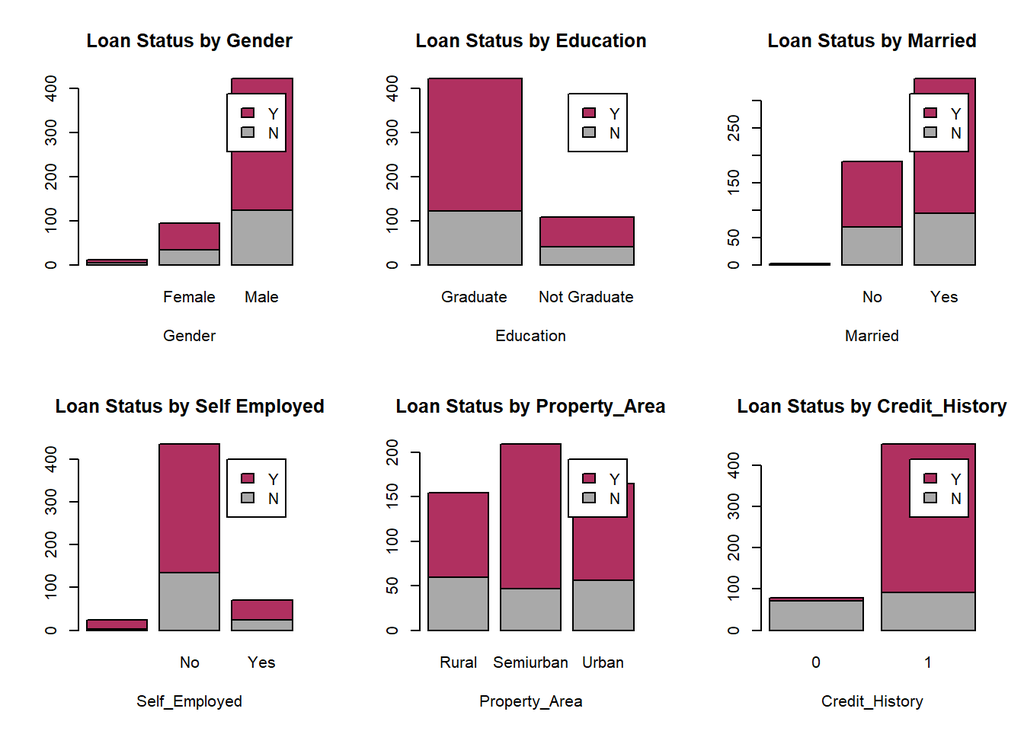

```r
par(mfrow=c(2,3))

counts <- table(data$Loan_Status, data$Gender)
barplot(counts, main="Loan Status by Gender",
        xlab="Gender", col=c("darkgrey","maroon"),
        legend = rownames(counts))

counts2 <- table(data$Loan_Status, data$Education)
barplot(counts2, main="Loan Status by Education",
        xlab="Education", col=c("darkgrey","maroon"),
        legend = rownames(counts2))

counts3 <- table(data$Loan_Status, data$Married)
barplot(counts3, main="Loan Status by Married",
        xlab="Married", col=c("darkgrey","maroon"),
        legend = rownames(counts3))

counts4 <- table(data$Loan_Status, data$Self_Employed)
barplot(counts4, main="Loan Status by Self Employed",
        xlab="Self_Employed", col=c("darkgrey","maroon"),
        legend = rownames(counts4))

counts5 <- table(data$Loan_Status, data$Property_Area)
barplot(counts5, main="Loan Status by Property_Area",
        xlab="Property_Area", col=c("darkgrey","maroon"),
        legend = rownames(counts5))

counts6 <- table(data$Loan_Status, data$Credit_History)
barplot(counts6, main="Loan Status by Credit_History",
        xlab="Credit_History", col=c("darkgrey","maroon"),
        legend = rownames(counts5))
```

# Decision Trees Part:

A decision tree is a supervised machine learning algorithm that can not only be used for both classification and regression problems, but also can be used to visualize the decision-making process by mapping out different potential outcomes. It create a set of binary splits on the predictor variables in order to create a tree that can be used to classify new observations into one of two groups.

The data is split into training and testing sets 70%/30%.

```r
set.seed(622)
sample <- createDataPartition(data$Loan_Status, p = 0.70, list = FALSE, times = 1)
trainnew <- data[sample, ]
testnew  <- data[-sample, ]
```

```r
dtree <- rpart(Loan_Status ~  Credit_History+Education+Self_Employed+Property_Area+LoanAmount+TotalIncome,method="class", data=trainnew,parms=list(split="information"))

dtree$cptable
```

```
##          CP nsplit rel error    xerror       xstd
## 1 0.4173913      0 1.0000000 1.0000000 0.07750794
## 2 0.0115942      1 0.5826087 0.5826087 0.06444927
## 3 0.0100000      4 0.5478261 0.6347826 0.06660820
```

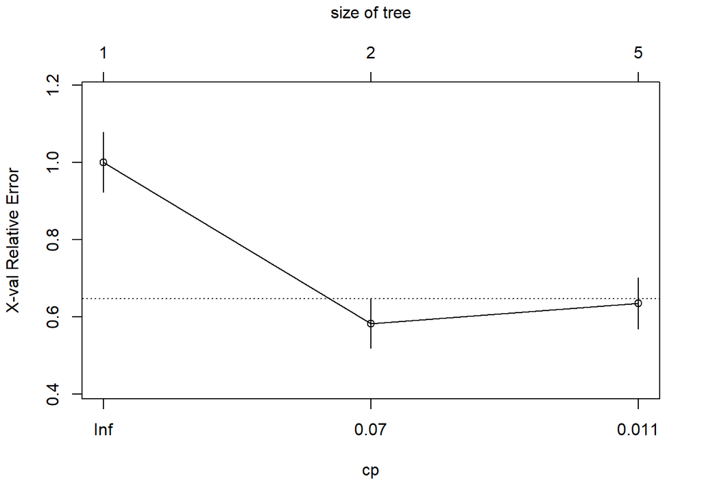

```r
plotcp(dtree)
```

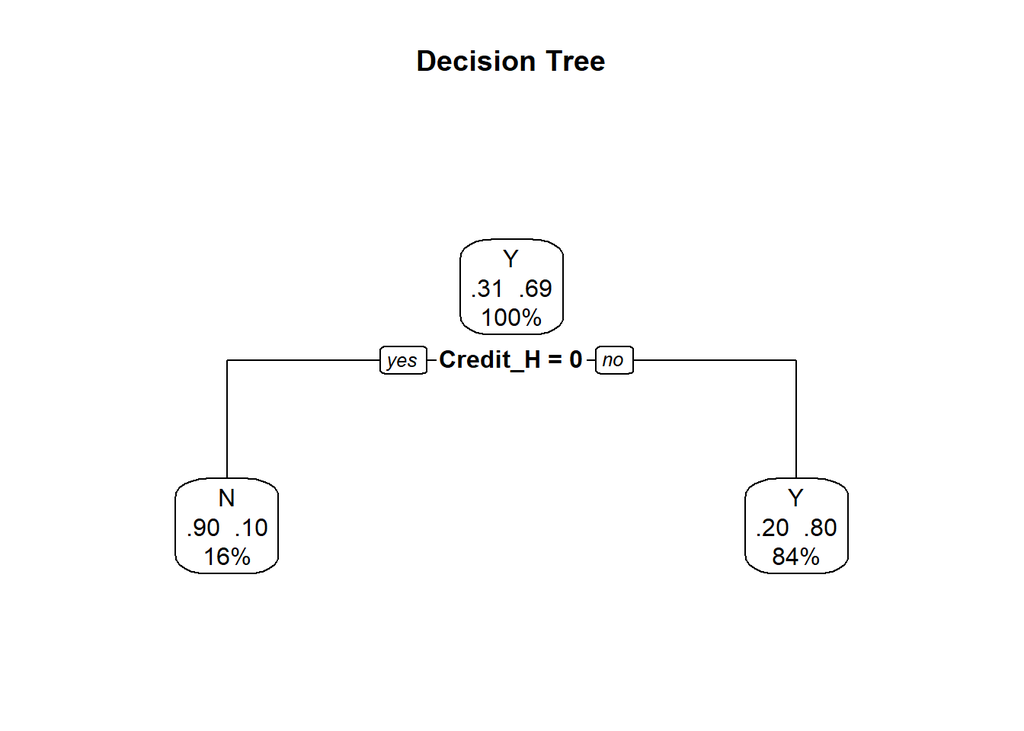

```r
dtree.pruned <- prune(dtree, cp=.02290076)
library(rpart.plot)
prp(dtree.pruned, type = 2, extra = 104,
    fallen.leaves = TRUE, main="Decision Tree")
```

```r
dtree.pred_train <- predict(dtree.pruned, trainnew, type="class")
dtree.perf_train <- table(trainnew$Loan_Status, dtree.pred_train,
                    dnn=c("Actual", "Predicted"))
dtree.perf_train
```

```
##       Predicted
## Actual   N   Y
##      N  54  61
##      Y   6 251
```

```r
dtree.cm_train <- confusionMatrix(dtree.pred_train, trainnew$Loan_Status)
dtree.cm_train
```

```
## Confusion Matrix and Statistics
##
##           Reference
## Prediction   N   Y
##          N  54   6
##          Y  61 251
##
##                Accuracy : 0.8199
##                  95% CI : (0.777, 0.8576)
##     No Information Rate : 0.6909
##     P-Value [Acc > NIR] : 1.131e-08
##
##                   Kappa : 0.5142
##
##  Mcnemar's Test P-Value : 4.191e-11
##
##             Sensitivity : 0.4696
##             Specificity : 0.9767
##          Pos Pred Value : 0.9000
##          Neg Pred Value : 0.8045
##              Prevalence : 0.3091
##          Detection Rate : 0.1452
##    Detection Prevalence : 0.1613
##       Balanced Accuracy : 0.7231
##
##        'Positive' Class : N
##
```

Use test dataset to analysis

```r
dtree_test <- rpart(Loan_Status ~ Credit_History+Education+Self_Employed+Property_Area+LoanAmount+TotalIncome,method="class", data=testnew,parms=list(split="information"))

dtree_test$cptable
```

```
##           CP nsplit rel error    xerror      xstd
## 1 0.35416667      0 1.0000000 1.0000000 0.1202660
## 2 0.02083333      1 0.6458333 0.6458333 0.1039142
## 3 0.01000000      7 0.5208333 0.7708333 0.1107900
```

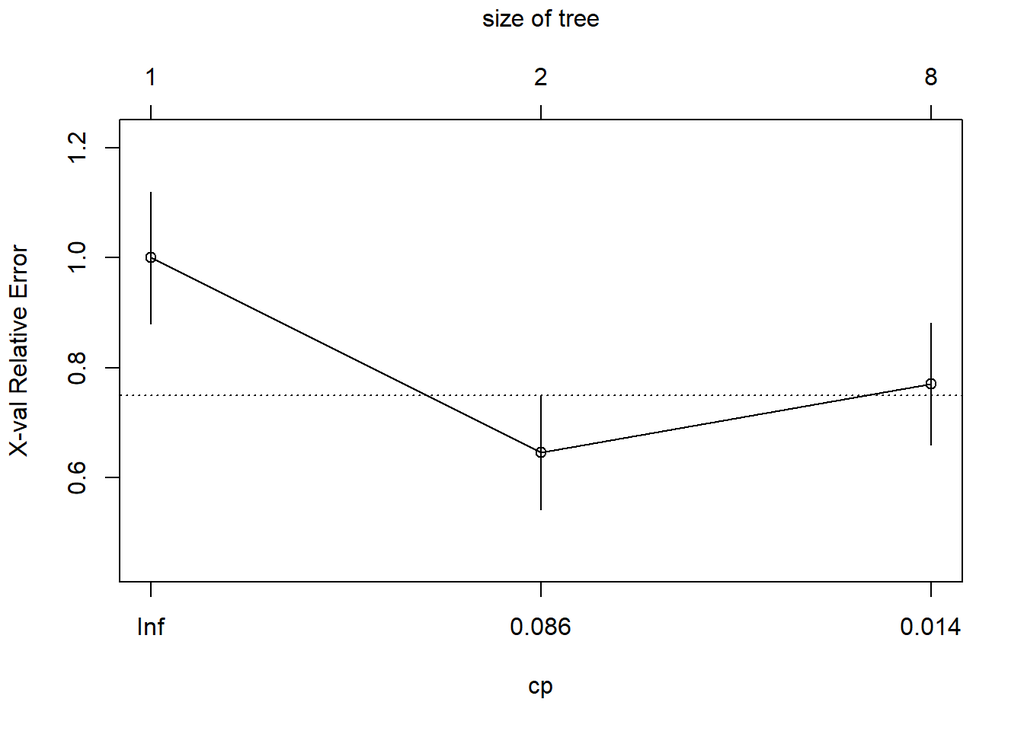

```r
plotcp(dtree_test)
```

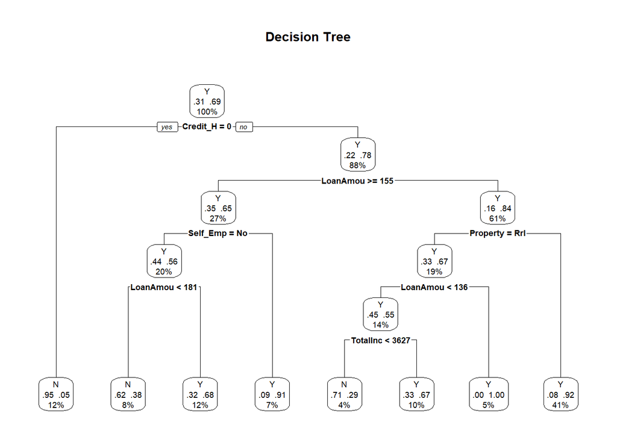

```r
dtree_test.pruned <- prune(dtree_test, cp=.01639344)
prp(dtree_test.pruned, type = 2, extra = 104,
    fallen.leaves = TRUE, main="Decision Tree")
```

```r
dtree_test.pred <- predict(dtree_test.pruned, newdata = testnew, type="class")
dtree_test.perf <- table(testnew$Loan_Status, dtree_test.pred,
                    dnn=c("Actual", "Predicted"))
dtree_test.perf
```

```
##       Predicted
## Actual   N   Y
##      N  31  17
##      Y   8 101
```

```r
dtree.cm_test <- confusionMatrix(dtree_test.pred, testnew$Loan_Status)
dtree.cm_test
```

```
## Confusion Matrix and Statistics
##
##           Reference
## Prediction   N   Y
##          N  31   8
##          Y  17 101
##
##                Accuracy : 0.8408
##                  95% CI : (0.774, 0.8942)
##     No Information Rate : 0.6943
##     P-Value [Acc > NIR] : 1.892e-05
##
##                   Kappa : 0.6041
##
##  Mcnemar's Test P-Value : 0.1096
##
##             Sensitivity : 0.6458
##             Specificity : 0.9266
##          Pos Pred Value : 0.7949
##          Neg Pred Value : 0.8559
##              Prevalence : 0.3057
##          Detection Rate : 0.1975
##    Detection Prevalence : 0.2484
##       Balanced Accuracy : 0.7862
##
##        'Positive' Class : N
##
```

Accuracy: Train data: 82% and Test data: 84.08%

# Random Trees Part:

Random Forest is a tree-based machine learning algorithm that leverages the power of multiple decision trees for making decisions. This approach develops multiple predictive models, and the results are aggregated to improve classification.

```r
library(randomForest)
```

```r
fit.forest <- randomForest(Loan_Status ~ Credit_History+Education+Self_Employed+Property_Area+LoanAmount+TotalIncome, data=trainnew)

fit.forest
```

```
##
## Call:
##  randomForest(formula = Loan_Status ~ Credit_History + Education +      Self_Employed + Property_Area + LoanAmount + TotalIncome,      data = trainnew)
##                Type of random forest: classification
##                      Number of trees: 500
## No. of variables tried at each split: 2
##
##         OOB estimate of  error rate: 19.35%
## Confusion matrix:
##    N   Y class.error
## N 56  59  0.51304348
## Y 13 244  0.05058366
```

```r
forest.pred <- predict(fit.forest, newdata = trainnew)
forest.cm <- table(trainnew$Loan_Status, forest.pred,
                     dnn=c("Actual", "Predicted"))
forest.cm
```

```
##       Predicted
## Actual   N   Y
##      N  82  33
##      Y   6 251
```

```r
forest.cm_train <- confusionMatrix(forest.pred, trainnew$Loan_Status)
forest.cm_train
```

```
## Confusion Matrix and Statistics
##
##           Reference
## Prediction   N   Y
##          N  82   6
##          Y  33 251
##
##                Accuracy : 0.8952
##                  95% CI : (0.8595, 0.9244)
##     No Information Rate : 0.6909
##     P-Value [Acc > NIR] : < 2.2e-16
##
##                   Kappa : 0.7375
##
##  Mcnemar's Test P-Value : 3.136e-05
##
##             Sensitivity : 0.7130
##             Specificity : 0.9767
##          Pos Pred Value : 0.9318
##          Neg Pred Value : 0.8838
##              Prevalence : 0.3091
##          Detection Rate : 0.2204
##    Detection Prevalence : 0.2366
##       Balanced Accuracy : 0.8448
##
##        'Positive' Class : N
##
```

Use test dataset to analysis

```r
fit.forest_test <- randomForest(Loan_Status ~ Credit_History+Education+Self_Employed+Property_Area+LoanAmount+TotalIncome, data=testnew)

fit.forest_test
```

```
##
## Call:
##  randomForest(formula = Loan_Status ~ Credit_History + Education +      Self_Employed + Property_Area + LoanAmount + TotalIncome,      data = testnew)
##                Type of random forest: classification
##                      Number of trees: 500
## No. of variables tried at each split: 2
##
##         OOB estimate of  error rate: 22.93%
## Confusion matrix:
##    N   Y class.error
## N 19  29  0.60416667
## Y  7 102  0.06422018
```

```r
forest.pred_test <- predict(fit.forest_test, newdata = testnew)
forest.cm_test <- table(testnew$Loan_Status, forest.pred_test,
                     dnn=c("Actual", "Predicted"))
forest.cm_test
```

```
##       Predicted
## Actual   N   Y
##      N  40   8
##      Y   0 109
```

```r
forest.cm_test <- confusionMatrix(forest.pred_test, testnew$Loan_Status)
forest.cm_test
```

```
## Confusion Matrix and Statistics
##
##           Reference
## Prediction   N   Y
##          N  40   0
##          Y   8 109
##
##                Accuracy : 0.949
##                  95% CI : (0.9021, 0.9777)
##     No Information Rate : 0.6943
##     P-Value [Acc > NIR] : 1.615e-15
##
##                   Kappa : 0.8741
##
##  Mcnemar's Test P-Value : 0.01333
##
##             Sensitivity : 0.8333
##             Specificity : 1.0000
##          Pos Pred Value : 1.0000
##          Neg Pred Value : 0.9316
##              Prevalence : 0.3057
##          Detection Rate : 0.2548
##    Detection Prevalence : 0.2548
##       Balanced Accuracy : 0.9167
##
##        'Positive' Class : N
##
```